# ML_project_TiU-7

The data pertains to the houses found in a given California district and some summary stats about them based on the 1990 census data. The columns are as follows, their names are pretty self-explanatory:

1. Median House Value: Median house value for households within a block (measured in US Dollars) [USD]
2. Median Income: Median income for households within a block of houses (measured in tens of thousands of US Dollars) [10kUSD]
3. Median Age: Median age of a house within a block; a lower number is a newer building [years]
4. Total Rooms: Total number of rooms within a block
5. Total Bedrooms: Total number of bedrooms within a block
6. Population: Total number of people residing within a block
7. Households: Total number of households, a group of people residing within a home unit, for a block
8. Latitude: A measure of how far north a house is; a higher value is farther north [°]
9. Longitude: A measure of how far west a house is; a higher value is farther west [°]
10. Distance to coast: Distance to the nearest coast point [m]
11. Distance to Los Angeles: Distance to the centre of Los Angeles [m]
12. Distance to San Diego: Distance to the centre of San Diego [m]
13. Distance to San Jose: Distance to the centre of San Jose [m]
14. Distance to San Francisco: Distance to the centre of San Francisco [m]

***1 point: Provide a clear explanation of the problem, the key objectives and goals, and how Machine Learning techniques (clustering, classification, and prediction) will be beneficial.***

In this dataset, we have data on the housing market in California. Variables convey information about the location of the of neighborhood, median housing price there, and some information on population density.

Key objectives are 1) to learn how to predict median housing price using several known variables ; 2) study housing market and find interesting relations that can help in the prediction modelling

Having this dataset and using ML techniques it is possible to

1. Analyze different patterns in the housing market in California with the use of clusterization. It is possible to find relationships between social-economical, house-specific and geographical variables in the housing market and find different groups.
2. Using predictive models, find a way how to estimate housing price based on given parameters. Additionally, it is possible to examine significance of each variable in the prediction models, so we can estimate which factors influence the housing prices more.

If we jump in the data, we see that all independent variables (so all variables in the dataset except for the median housing prices) are known from the beginning. That is because we can find data on population from several statistical bureaus and geographical data are very easily obtainable.

As all independent variables are known, it is always easy to use trained models for estimation which can further be applied in the business context.

***2 points: Research on novel approaches and related research works implemented in the context of your selected task. Identify key challenges and State-of-the-Art (SotA) techniques from the literature review.***

- **Clustering for Market Segmentation**  
  Research Paper: *"Review of Clustering Methods Used in Data-Driven Housing Market Segmentation"*  
  This paper highlights the utility of clustering algorithms such as K-Means and DBSCAN for grouping houses with similar characteristics. It supports our use of clustering to uncover hidden patterns in the California housing market, focusing on price differences and location. These insights provide better understanding of housing market segments and their unique attributes. Link to Research Paper:https://www.researchgate.net/publication/373743133_Review_of_Clustering_Methods_Used_in_Data-Driven_Housing_Market_Segmentation
- **Predictive Modeling for Price Estimation**  
  Research Paper: *"Predicting Property Prices with Machine Learning Algorithms"*  
  This study demonstrates the effectiveness of algorithms like Random Forest and Gradient Boosting in property price prediction. It underscores the trade-offs between achieving high accuracy and maintaining interpretability, guiding our objective to balance these aspects. Additionally, it frames our research around managing multicollinearity and capturing non-linear relationships in housing data. Link to Research Paper:https://www.researchgate.net/publication/346308101_Predicting_property_prices_with_machine_learning_algorithms
- **Feature Engineering and Advanced Regression**  
  Research Paper: *"Advanced Machine Learning Techniques for Predictive Modeling of Property Prices"*  
  This research emphasizes the importance of incorporating advanced feature engineering and regression models to improve prediction accuracy. It identifies gaps in integrating location and macroeconomic variables, aligning with our plan to include these features. The findings motivate our exploration of how geographical and economic factors influence housing prices. Link to Research Paper:https://www.researchgate.net/publication/380803669_Advanced_Machine_Learning_Techniques_for_Predictive_Modeling_of_Property_Prices

***1 point: Identify and explain the types of Machine Learning tasks that need to be applied (e.g., cleaning, data transformation, scaling, normalization etc.) and are relevant to the problem. Provide an initial high-level diagram of the architecture and workflow of your approach.***

According to the dataset author, the dataset was already cleaned. However, some outliers could be dropped (for example, several extremely expensive neighborhoods such as Beverly Hills in LA, or vice versa ghetos in Skidrow district).

Standard scaling should be applied for variables that will be used in clusterizations. It is necessary since clusterization algorithms cannot work properly without scaling as they use distances in their code.

Additionally, standard scaling should be used for all variables in the regression problems. Reason for this is because it can reduce the time complexity and save some time.

Our workflow:

1. Analyse data using diagrams / descriptive statistics in order to get as much understanding from data as possible. Find relationships with different variables and explore their distributions.
2. Clean data and prepare it for further analysis (clusterizations and regressions) if necessary.
3. Use clusterization techniques to get more insight on data distributions.
4. Prepare data for the predictive modeling (split on train and validation set). Complete feature selection, prepare first model and check their performance.
5. Fine tune model using validation set, find optimal parameters for all chosen variables. Explore this models. Get results on the test sets.

```python
import pandas as pd
import numpy as np
import seaborn as sns
import matplotlib.pyplot as plt
from sklearn.preprocessing import StandardScaler
from sklearn.cluster import DBSCAN
from sklearn.cluster import KMeans
import seaborn as sns
from mpl_toolkits.mplot3d import Axes3D
from sklearn.decomposition import PCA
from sklearn.linear_model import LinearRegression
from sklearn.model_selection import train_test_split
from sklearn.metrics import mean_absolute_error, mean_squared_error, r2_score
from xgboost import XGBRegressor
from sklearn.ensemble import RandomForestRegressor
from sklearn.linear_model import Lasso
from sklearn.linear_model import Ridge
from sklearn.metrics import silhouette_score
from sklearn.ensemble import IsolationForest
from statsmodels.stats.outliers_influence import variance_inflation_factor
from statsmodels.tools.tools import add_constant
from sklearn.model_selection import GridSearchCV
from sklearn.metrics import mean_squared_error, make_scorer
from sklearn.preprocessing import StandardScaler, PolynomialFeatures
from sklearn.linear_model import ElasticNet
from sklearn.ensemble import IsolationForest
from sklearn.base import BaseEstimator, TransformerMixin
```

```python
data = pd.read_csv('California_Houses.csv')
```

```python
data.sample(5)
```

|  | Median_House_Value | Median_Income | Median_Age | Tot_Rooms | Tot_Bedrooms | Population | Households | Latitude | Longitude | Distance_to_coast | Distance_to_LA | Distance_to_SanDiego | Distance_to_SanJose | Distance_to_SanFrancisco |
| --- | --- | --- | --- | --- | --- | --- | --- | --- | --- | --- | --- | --- | --- | --- |
| 13777 | 122800.0 | 3.3365 | 20 | 3111 | 563 | 1453 | 538 | 34.02 | -117.08 | 84587.526504 | 107287.530142 | 145222.880195 | 569856.553475 | 637429.275609 |
| 1224 | 122300.0 | 2.6417 | 13 | 4110 | 847 | 1796 | 706 | 38.20 | -120.57 | 85085.470023 | 506278.668968 | 683388.661950 | 150878.373202 | 169856.835117 |
| 1073 | 125200.0 | 4.3309 | 28 | 2551 | 378 | 1011 | 374 | 39.75 | -121.80 | 170356.087709 | 707931.509289 | 885614.731767 | 268604.200072 | 226437.520328 |
| 11895 | 82200.0 | 2.7596 | 32 | 1625 | 335 | 1212 | 327 | 33.97 | -117.36 | 62224.994838 | 81962.858268 | 140686.346369 | 554654.282206 | 622470.842895 |
| 16765 | 275600.0 | 4.5000 | 36 | 1344 | 258 | 782 | 265 | 37.69 | -122.49 | 4239.234145 | 556656.713967 | 734806.927627 | 65775.472131 | 10669.369412 |

# Part 1: EDA

## Part 1.1: Potential challanges:

Correlated variables, which can lead to multicollinearity.

Continuously distributed data, which can lead to problems with clusterizations.

Distance to the city is noisy. Using only 3 distances, we can get the coordinate of this district, and therefore getting the 4th distance. At the same time, Longtitude and Lattitude gives us the same information.

```python
data.describe()
```

|  | Median_House_Value | Median_Income | Median_Age | Tot_Rooms | Tot_Bedrooms | Population | Households | Latitude | Longitude | Distance_to_coast | Distance_to_LA | Distance_to_SanDiego | Distance_to_SanJose | Distance_to_SanFrancisco |
| --- | --- | --- | --- | --- | --- | --- | --- | --- | --- | --- | --- | --- | --- | --- |
| count | 20640.000000 | 20640.000000 | 20640.000000 | 20640.000000 | 20640.000000 | 20640.000000 | 20640.000000 | 20640.000000 | 20640.000000 | 20640.000000 | 2.064000e+04 | 2.064000e+04 | 20640.000000 | 20640.000000 |
| mean | 206855.816909 | 3.870671 | 28.639486 | 2635.763081 | 537.898014 | 1425.476744 | 499.539680 | 35.631861 | -119.569704 | 40509.264883 | 2.694220e+05 | 3.981649e+05 | 349187.551219 | 386688.422291 |
| std | 115395.615874 | 1.899822 | 12.585558 | 2181.615252 | 421.247906 | 1132.462122 | 382.329753 | 2.135952 | 2.003532 | 49140.039160 | 2.477324e+05 | 2.894006e+05 | 217149.875026 | 250122.192316 |
| min | 14999.000000 | 0.499900 | 1.000000 | 2.000000 | 1.000000 | 3.000000 | 1.000000 | 32.540000 | -124.350000 | 120.676447 | 4.205891e+02 | 4.849180e+02 | 569.448118 | 456.141313 |
| 25% | 119600.000000 | 2.563400 | 18.000000 | 1447.750000 | 295.000000 | 787.000000 | 280.000000 | 33.930000 | -121.800000 | 9079.756762 | 3.211125e+04 | 1.594264e+05 | 113119.928682 | 117395.477505 |
| 50% | 179700.000000 | 3.534800 | 29.000000 | 2127.000000 | 435.000000 | 1166.000000 | 409.000000 | 34.260000 | -118.490000 | 20522.019101 | 1.736675e+05 | 2.147398e+05 | 459758.877000 | 526546.661701 |
| 75% | 264725.000000 | 4.743250 | 37.000000 | 3148.000000 | 647.000000 | 1725.000000 | 605.000000 | 37.710000 | -118.010000 | 49830.414479 | 5.271562e+05 | 7.057954e+05 | 516946.490963 | 584552.007907 |
| max | 500001.000000 | 15.000100 | 52.000000 | 39320.000000 | 6445.000000 | 35682.000000 | 6082.000000 | 41.950000 | -114.310000 | 333804.686371 | 1.018260e+06 | 1.196919e+06 | 836762.678210 | 903627.663298 |

```python
data.isna().sum()

#We have no missing values in this dataframe
```

|  | 0 |
| --- | --- |
| Median_House_Value | 0 |
| Median_Income | 0 |
| Median_Age | 0 |
| Tot_Rooms | 0 |
| Tot_Bedrooms | 0 |
| Population | 0 |
| Households | 0 |
| Latitude | 0 |
| Longitude | 0 |
| Distance_to_coast | 0 |
| Distance_to_LA | 0 |
| Distance_to_SanDiego | 0 |
| Distance_to_SanJose | 0 |
| Distance_to_SanFrancisco | 0 |

**dtype:** int64

## Plots

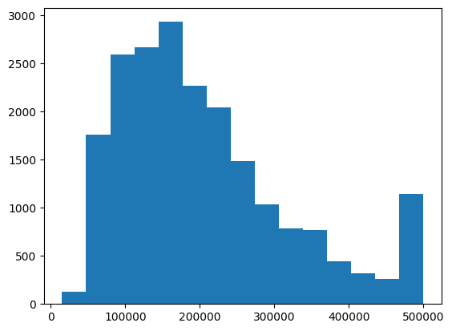

```python
plt.hist(data['Median_House_Value'], bins=15)
```

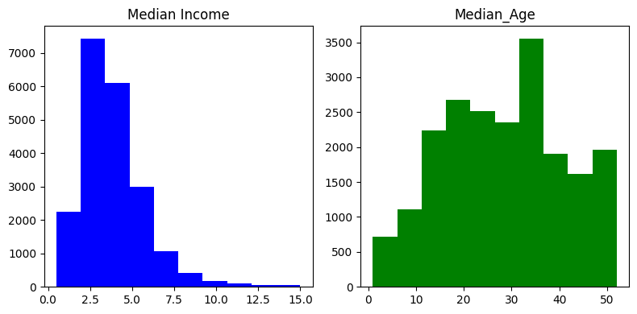

```python
# Create a 2x
fig, ax = plt.subplots(1, 2, figsize=(8, 4))
ax[0].hist(data['Median_Income'],bins=10, color='blue')
ax[0].set_title("Median Income")

ax[1].hist(data['Median_Age'],bins=10, color='green')
ax[ 1].set_title("Median_Age")

plt.tight_layout()
plt.show()
```

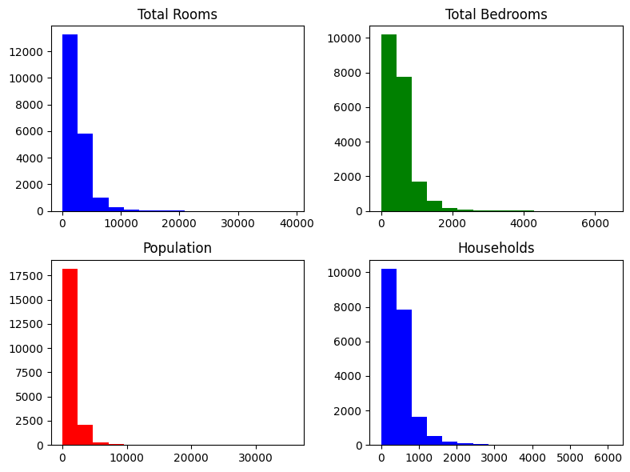

```python
# Create a 2x2 grid of subplots
fig, ax = plt.subplots(2, 2, figsize=(8, 6))  # 2 rows, 2 columns

# Plot each graph in its respective subplot
ax[0, 0].hist(data['Tot_Rooms'],bins=15, color='blue')
ax[0, 0].set_title("Total Rooms")

ax[0, 1].hist(data['Tot_Bedrooms'],bins=15, color='green')
ax[0, 1].set_title("Total Bedrooms")

ax[1, 0].hist(data['Population'], bins=15, color='red')
ax[1, 0].set_title("Population")

ax[1, 1].hist(data['Households'],bins=15, color='blue')
ax[1, 1].set_title("Households")


# Adjust layout for better spacing
plt.tight_layout()
plt.show()

#They are very similar
```

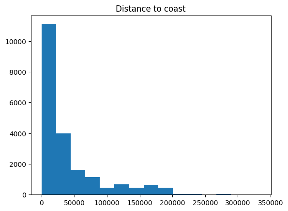

```python
plt.hist(data['Distance_to_coast'], bins=15)
plt.title('Distance to coast')
```

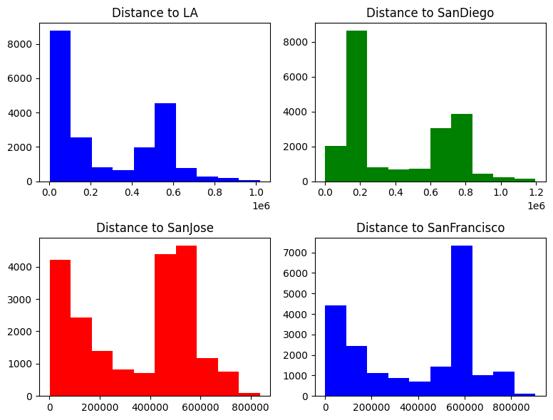

```python
fig, ax = plt.subplots(2, 2, figsize=(8, 6))

ax[0, 0].hist(data['Distance_to_LA'],bins=10, color='blue')
ax[0, 0].set_title("Distance to LA")

ax[0, 1].hist(data['Distance_to_SanDiego'],bins=10, color='green')
ax[0, 1].set_title("Distance to SanDiego")

ax[1, 0].hist(data['Distance_to_SanJose'], bins=10, color='red')
ax[1, 0].set_title("Distance to SanJose")

ax[1, 1].hist(data['Distance_to_SanFrancisco'],bins=10, color='blue')
ax[1, 1].set_title("Distance to SanFrancisco")

plt.tight_layout()
plt.show()


# From here we see problem with data - a lot of houses are in LA or close to it
# But generally, we can see from here how many of them are in each city
```

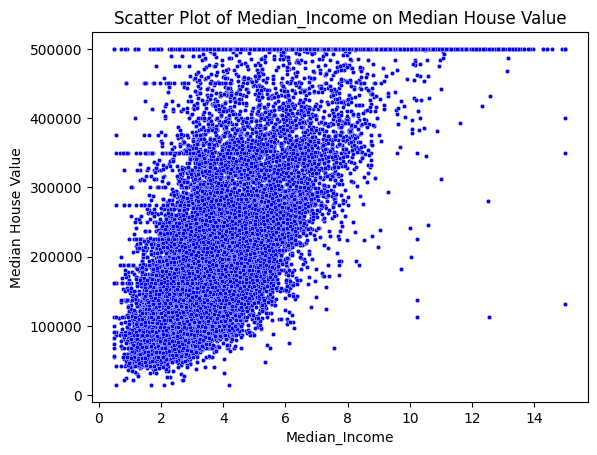

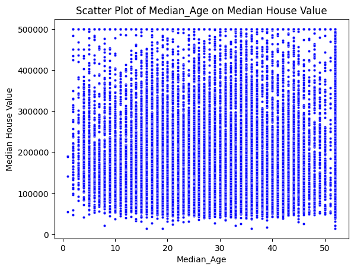

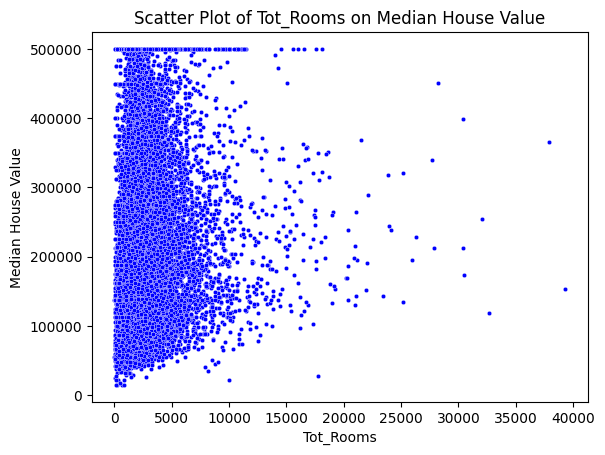

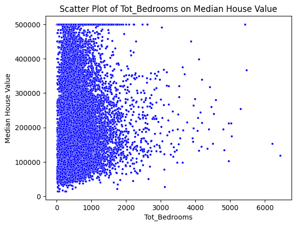

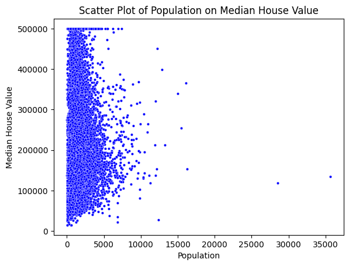

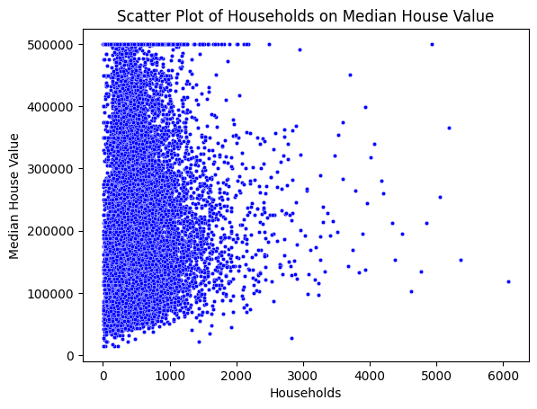

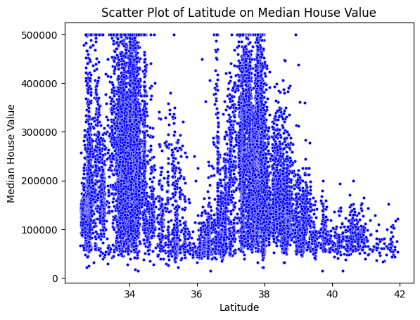

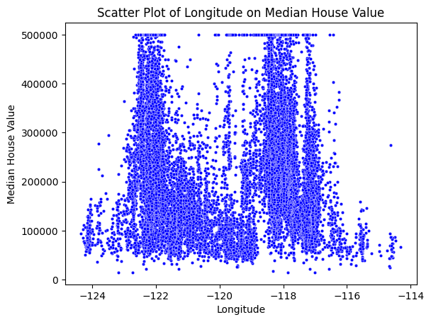

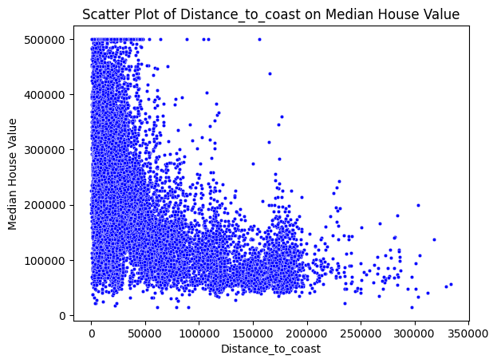

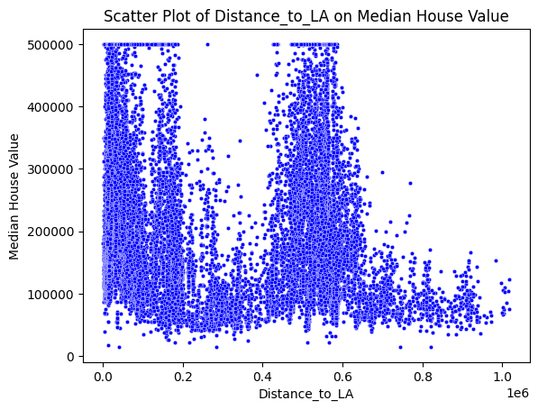

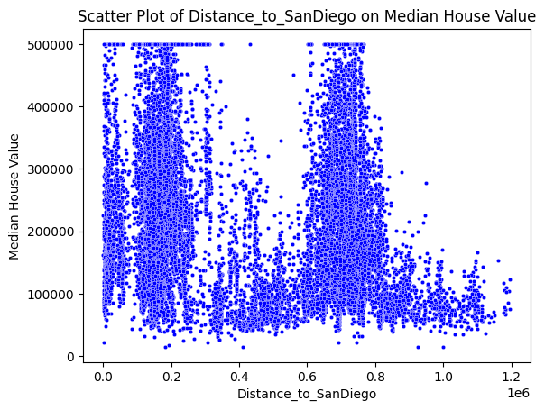

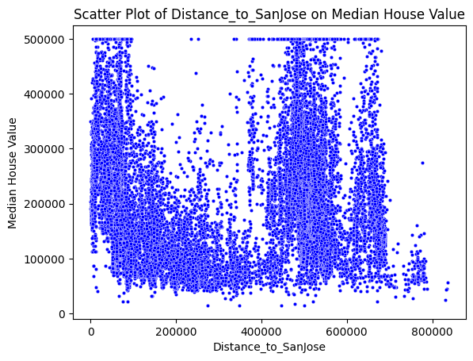

[1 more figures not shown]

```python
for name in data.columns[1:]:
  sns.scatterplot(x=data[name].values, y=data['Median_House_Value'].values, color='blue', s=10)
  plt.title(f"Scatter Plot of {name} on Median House Value")
  plt.xlabel(f"{name}")
  plt.ylabel("Median House Value")
  plt.show()
```

From this set of scatterplots, we see that our dependent variable doesn't have exact linear relations with features, as well as any functional.

We mostly see chaotic relationships.

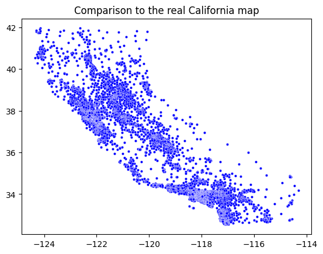

```python
sns.scatterplot(x=data['Longitude'].values, y=data['Latitude'].values, color='blue', s=10)
plt.title("Comparison to the real California map")
plt.show()

#This really looks like California
#This map is done only to check how our data points are distributed on the map
```

In all this plots, we see that there are outlier for the following variables:

1. Total rooms (from the right side)
2. Total Bedrooms (from the right side)
3. Population
4. Households
5. Median Income
6. Distance to coast
7. Median_House_Value

For this, we are going to omit this data

```python
data.shape[0]
#What is the size of dataset before dropping outliers
```

```
20640
```

```python
iso = IsolationForest(contamination=0.05, random_state=42)
outliers = iso.fit_predict(data)

data_cleaned = data[outliers == 1]
print(data_cleaned)
```

```
       Median_House_Value  Median_Income  Median_Age  Tot_Rooms  Tot_Bedrooms  \
0                452600.0         8.3252          41        880           129
1                358500.0         8.3014          21       7099          1106
2                352100.0         7.2574          52       1467           190
3                341300.0         5.6431          52       1274           235
4                342200.0         3.8462          52       1627           280
...                   ...            ...         ...        ...           ...
20635             78100.0         1.5603          25       1665           374
20636             77100.0         2.5568          18        697           150
20637             92300.0         1.7000          17       2254           485
20638             84700.0         1.8672          18       1860           409
20639             89400.0         2.3886          16       2785           616

       Population  Households  Latitude  Longitude  Distance_to_coast  \
0             322         126     37.88    -122.23        9263.040773
```

[output cut: 38 more lines]

```python
data_cleaned.shape[0]
#How many are left after outlier cleaning
```

```
19608
```

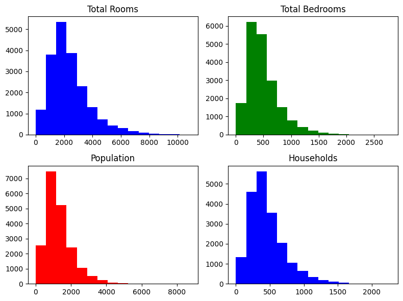

```python
fig, ax = plt.subplots(2, 2, figsize=(8, 6))  # 2 rows, 2 columns

# Plot each graph in its respective subplot
ax[0, 0].hist(data_cleaned['Tot_Rooms'],bins=15, color='blue')
ax[0, 0].set_title("Total Rooms")

ax[0, 1].hist(data_cleaned['Tot_Bedrooms'],bins=15, color='green')
ax[0, 1].set_title("Total Bedrooms")

ax[1, 0].hist(data_cleaned['Population'], bins=15, color='red')
ax[1, 0].set_title("Population")

ax[1, 1].hist(data_cleaned['Households'],bins=15, color='blue')
ax[1, 1].set_title("Households")


# Adjust layout for better spacing
plt.tight_layout()
plt.show()
```

Now these variables look like having less outliers

We have a lot of data entries, therefore reducing them by 1032 is not problematic.

```python
data=data_cleaned.copy()
```

```python
data.shape
```

```
(19608, 14)
```

## Correlations

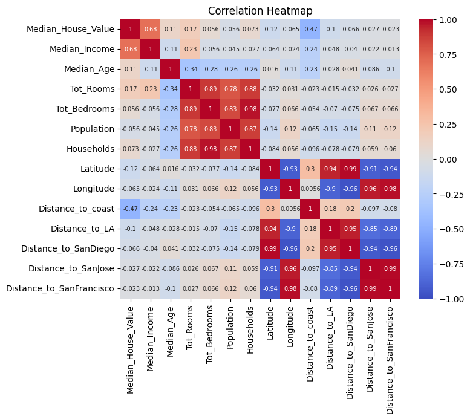

```python
corr_matrix = data.corr()

# Plot the heatmap
plt.figure(figsize=(8, 6))
sns.heatmap(corr_matrix, annot=True, cmap='coolwarm',annot_kws={'size': 7}, vmin=-1, vmax=1, square=True)
plt.title("Correlation Heatmap")
plt.show()
```

[output not shown]

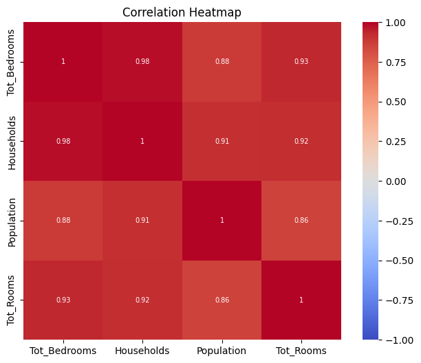

```python
print(data[['Tot_Bedrooms','Households','Population','Tot_Rooms']].corr())

plt.figure(figsize=(8, 6))
sns.heatmap(data[['Tot_Bedrooms','Households','Population','Tot_Rooms']].corr(),
            annot=True, cmap='coolwarm',annot_kws={'size': 7}, vmin=-1, vmax=1, square=True)
plt.title("Correlation Heatmap")
plt.show()
```

We have 3 blocks of information

1. Income and Age - characteristics of neighborhood inhabitants and houses there.
2. Population, Total Rooms and Bedrooms, Number of households - basically about the size/density of a neighborhood. We don't need all these columns for sure as they flow one from another
3. Geographical: Distances to cities, Longtitude/Latitude. We need decided which will be omitted and which we need to take. It seems to be important as if district is close to those cities, prices should be higher. The same works with coast. But on the other hand, Longtitude and Latitude give the same info.

Problems here:

1. Multicollinearity.
2. Low correlations between Mediah House Value and other variables.

Ideas:

1. Median Income: Higher Income - higher house value
2. Population, Total Rooms, Total Bedrooms, Households: more of them - means its a block of flats district. House values lower.
3. Distances: closer to cities - higher prices. LA the most expensive one, then it should have the most of expensive houses. The same works with distance to the coast. Houses that are closer to the coast, should be more expensive.

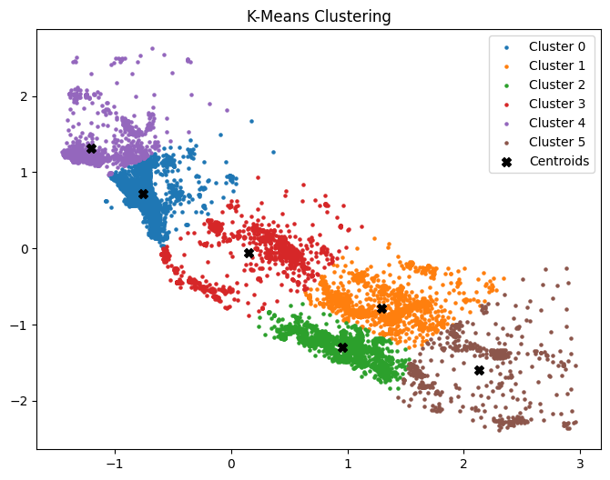

```python
X = data[['Latitude','Longitude']]
scaler= StandardScaler()
X_scaled = scaler.fit_transform(X)

kmeans = KMeans(n_clusters=6, random_state=0)
kmeans.fit(X_scaled)

labels = kmeans.labels_
centroids = kmeans.cluster_centers_

plt.figure(figsize=(8, 6))
unique_labels = set(labels)
for label in unique_labels:
    label_mask = labels == label
    plt.scatter(X_scaled[label_mask, 0], X_scaled[label_mask, 1], s=5, label=f'Cluster {label}')

plt.scatter(centroids[:, 0], centroids[:, 1], s=50, c='black', marker='X', label='Centroids')
plt.title("K-Means Clustering")
plt.legend()
plt.show()

#This doesn't give us much of information, but generally shows us what is the distribution of districts in data across state and the centers
#n=6 is chosen by 4 cities + rural areas of state
```

## DBSCAN

```python
eps = 0.1
min_samples = 5

# Iterate over all pairs of features
for feature_pair in combinations(data.columns, 2):
    feature1, feature2 = feature_pair
    X = data[[feature1, feature2]].values
    scaler=StandardScaler()
    X=scaler.fit_transform(X)

    # Apply DBSCAN
    dbscan = DBSCAN(eps=eps, min_samples=min_samples)
    labels = dbscan.fit_predict(X)

    # Plot the results
    plt.figure(figsize=(8, 6))
    plt.scatter(X[:, 0], X[:, 1], c=labels, cmap='viridis', s=10)
    plt.title(f"DBSCAN on {feature1} vs {feature2}")
    plt.xlabel(feature1)
    plt.ylabel(feature2)
    plt.colorbar(label="Cluster Label")
    plt.show()

    # Print unique cluster labels
    unique_labels = np.unique(labels)
    n_noise = list(labels).count(-1)
    print(f"Features: {feature1} & {feature2}")
    print(f"Unique cluster labels: {unique_labels}")
    print(f"Number of noise points: {n_noise}\n")


    ### If you unhide output below, you can find 91 amazing scatterplt
```

[output not shown]

```python
eps = 0.1
min_samples = 5

for feature_triplet in combinations(data.columns, 3):
    feature1, feature2, feature3 = feature_triplet
    X = data[[feature1, feature2, feature3]].values
    scaler = StandardScaler()
    X = scaler.fit_transform(X)

    # Apply DBSCAN
    dbscan = DBSCAN(eps=eps, min_samples=min_samples)
    labels = dbscan.fit_predict(X)

    # Plot the results
    fig = plt.figure(figsize=(10, 8))
    ax = fig.add_subplot(111, projection='3d')
    scatter = ax.scatter(X[:, 0], X[:, 1], X[:, 2], c=labels, cmap='viridis', s=10)
    ax.set_title(f"DBSCAN on {feature1}, {feature2}, {feature3}")
    ax.set_xlabel(feature1)
    ax.set_ylabel(feature2)
    ax.set_zlabel(feature3)
    plt.colorbar(scatter, ax=ax, label="Cluster Label")
    plt.show()

    # Print unique cluster labels
    unique_labels = np.unique(labels)
    n_noise = list(labels).count(-1)
    print(f"Features: {feature1}, {feature2}, {feature3}")
    print(f"Unique cluster labels: {unique_labels}")
    print(f"Number of noise points: {n_noise}\n")
```

[output not shown]

We implemented a search for parameters that will give the highest score.

```
Optimal epsilon: 0.4
Optimal min_samples: 11
Best silhouette score: 0.5760016515265891
```

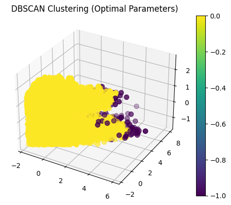

```python
#our final
X=data[[ 'Tot_Rooms','Tot_Bedrooms', 'Latitude' ]]
scaler=StandardScaler()
X=scaler.fit_transform(X)

epsilon_range = np.linspace(0.01, 0.4, 10)  # Adjust range and step size as needed
min_samples_range = range(5, 16,2)

# Variables to store optimal parameters and scores
best_epsilon = None
best_min_samples = None
best_score = -1

# Grid search over epsilon and min_samples
for epsilon in epsilon_range:
    for min_samples in min_samples_range:
        # Apply DBSCAN
        model = DBSCAN(eps=epsilon, min_samples=min_samples)
        labels = model.fit_predict(X)

        # Skip iterations where DBSCAN identifies no clusters
        if len(set(labels)) <= 1:  # Only noise or single cluster
            continue

        # Calculate silhouette score (only works if more than 1 cluster exists)
        score = silhouette_score(X, labels)

        # Update best parameters if this combination is better
        if score > best_score:
            best_score = score
            best_epsilon = epsilon
            best_min_samples = min_samples

# Output results
print(f"Optimal epsilon: {best_epsilon}")
print(f"Optimal min_samples: {best_min_samples}")
print(f"Best silhouette score: {best_score}")

# Optional: Visualize clusters for the optimal parameters
model = DBSCAN(eps=best_epsilon, min_samples=best_min_samples)
labels = model.fit_predict(X)

# Plot the 3D clusters
fig = plt.figure()
ax = fig.add_subplot(111, projection='3d')
scatter = ax.scatter(X[:, 0], X[:, 1], X[:, 2], c=labels, cmap='viridis', s=50)
plt.colorbar(scatter)
plt.title("DBSCAN Clustering (Optimal Parameters)")
plt.show()
```

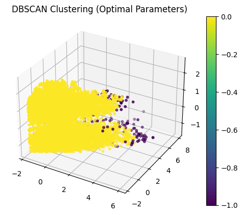

```python
model = DBSCAN(eps=0.4, min_samples=11)
labels = model.fit_predict(X)

# Plot the 3D clusters
fig = plt.figure()
ax = fig.add_subplot(111, projection='3d')
scatter = ax.scatter(X[:, 0], X[:, 1], X[:, 2], c=labels, cmap='viridis', s=10)
plt.colorbar(scatter)
plt.title("DBSCAN Clustering (Optimal Parameters)")
plt.show()
```

```
Optimal epsilon: 1.0
Optimal min_samples: 3
Best silhouette score: 0.7833535692119474
```

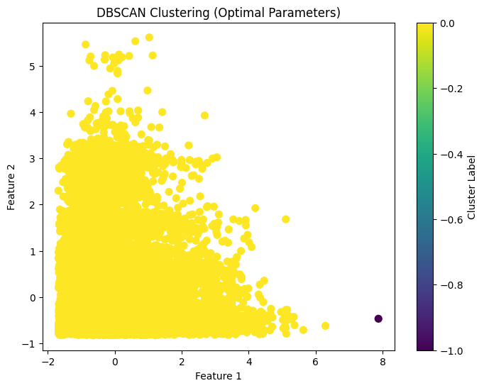

```python
X=data[['Tot_Bedrooms','Distance_to_coast' ]]
scaler=StandardScaler()
X=scaler.fit_transform(X)

epsilon_range = np.linspace(0.05, 1.0, 10)  # Adjust range and step size as needed
min_samples_range = range(3, 16,2)

# Variables to store optimal parameters and scores
best_epsilon = None
best_min_samples = None
best_score = -1

# Grid search over epsilon and min_samples
for epsilon in epsilon_range:
    for min_samples in min_samples_range:
        # Apply DBSCAN
        model = DBSCAN(eps=epsilon, min_samples=min_samples)
        labels = model.fit_predict(X)

        # Skip iterations where DBSCAN identifies no clusters
        if len(set(labels)) <= 1:  # Only noise or single cluster
            continue

        # Calculate silhouette score (only works if more than 1 cluster exists)
        score = silhouette_score(X, labels)

        # Update best parameters if this combination is better
        if score > best_score:
            best_score = score
            best_epsilon = epsilon
            best_min_samples = min_samples

# Output results
print(f"Optimal epsilon: {best_epsilon}")
print(f"Optimal min_samples: {best_min_samples}")
print(f"Best silhouette score: {best_score}")

# Optional: Visualize clusters for the optimal parameters
model = DBSCAN(eps=best_epsilon, min_samples=best_min_samples)
labels = model.fit_predict(X)

# Plot the 2D clusters
plt.figure(figsize=(8, 6))
scatter = plt.scatter(X[:, 0], X[:, 1], c=labels, cmap='viridis', s=50)
plt.colorbar(scatter, label='Cluster Label')
plt.title("DBSCAN Clustering (Optimal Parameters)")
plt.xlabel("Feature 1")
plt.ylabel("Feature 2")
plt.show()
```

Here we see that these DBSCAN basically suggest that all points are from the same cluster.

We are not getting any insights from them

There is a theoretical reason behind that - in the way how DBSCAN operates.

While Kmeans just "throws" n points as centroids and then repeats this until algorithm converges, DBSCAN operates in a different way.

DBSCAN marks point in 3 different classes: inside points, border points and noisy point. Each inside point should have at least M (min_sample parameter) within epsilon (eps parameter) distance. Border points lie within epsilon distance but have less than M points of this class. Noisy points don't respect these two conditions. So if there is, for example, a dataset which is on the scatterplot is just a straight line made out of many points, it will obviously be marked as a single cluster (while kmeans will set few different clusters).

What could be done: using PCA new features can be created, but we decided not to go in that direction because with PCA the meaning of variables is getting lost, therefore none insights can be obtained. It will not increase our understanding of data and will not give us any ideas that can be later used in the predictive analysis.

Also we could do it just based on locations, but it will be just a cartography in which we are not very interested.